# Accessing UFO sightings data

Colleen Nell

2016-12-05

This package currently provides 2 functions to gather data on UFO sightings from the National UFO Report Center (www.nuforc.org). These functions take dates and return sightings data.

To install this package:

```r
library(devtools)
library(ggplot2)

install_github("collnell/Xfiles")
library(Xfiles)
```

## UFOcount()

This function returns a dataframe containing the total count of UFO observations for a given month & year. Dates need to be entered in a ‘YYYY-mm’ format

```r
UFOcount(date='2016-11')
```

```
##         Date UFOs
## 1 2016-11-01  160
```

If no date is provided, by default all monthly observations on record are returned by date.

```r
df<-UFOcount()
str(df)
```

```
## 'data.frame':    891 obs. of  2 variables:
##  $ Date: Date, format: "2016-11-01" "2016-10-01" ...
##  $ UFOs: int  160 454 574 532 665 415 377 380 405 424 ...
```

The UFO records contain 891 month records. This includes data from WAY back, which might not be very reliable. Consistent monthly records on UFO sightings begin around 1950.

```r
df<-filter(df, df$Date>=as.Date('1950-01-01'))
str(df)
```

```
## 'data.frame':    783 obs. of  2 variables:
##  $ Date: Date, format: "2016-11-01" "2016-10-01" ...
##  $ UFOs: int  160 454 574 532 665 415 377 380 405 424 ...
```

The theme_UFO() theme for ggplot2 may come in handy in plotting sightings data:

UFO monthly sightings since 1950

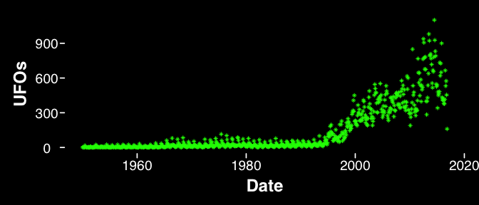

```r
ggplot(df, aes(x=Date, y=UFOs))+geom_point(size=1, shape=8, color="green")+theme_UFO()
```

```r
df$year<-as.integer(year(df$Date))
df$month<-as.integer(month(df$Date))
df<-top_n(df,25)
```

[output not shown]

[figure not shown]

```r
ggplot(df, aes(x=month, y=UFOs, group=year, color=year))+geom_line()+theme_UFO()+scale_color_continuous(low="greenyellow", high="green4")
```

## UFOobs()

This function gathers higher resolution data on each UFO sighting for a given month and year. Data returned include: Date, City, State, Shape, and a Summary.

```r
df<-UFOobs(year=1980, month=01)
```

```
## No encoding supplied: defaulting to UTF-8.
```

```r
str(df)
```

```
## 'data.frame':    15 obs. of  8 variables:
##  $ City    : chr  "Virginia Beach" "Murphy/Arnold" "Los Angeles" "Pittsburgh (north of)" ...
##  $ State   : chr  "VA" "CA" "CA" "PA" ...
##  $ Shape   : chr  "Cylinder" "Sphere" "Diamond" "Oval" ...
##  $ Duration: chr  "20 Minutes" "45 Minutes" "2 minutes" "15 min." ...
##  $ Summary : chr  "A \"cylinder [shaped] object” that had a “white light with a red dot”  and was “over roof top” and then “went behind the houses"| __truncated__ "Tracked by a UFO" "Spinning metallic diamonds over Super Bowl" "Two glowing disks seen over an Interstate highway in Western Pennsylv…
##  $ Date    : Date, format: "1980-01-23" "1980-01-22" ...
##  $ Month   : num  1 1 1 1 1 1 1 1 1 1 ...
##  $ Year    : num  1980 1980 1980 1980 1980 1980 1980 1980 1980 1980 ...
```

Observation data can also be drawn for a date range. Warning: this is a larger dataset and may take a while if requesting a large date range. It is adviseable to use to UFOcount() function to consider the number of observations in the data first.

```r
df<-UFOobs(year=2014, month=01, year_end= 2016, month_end = 12)

se <- function(x) sd(x)/sqrt(length(x))

df<-df%>%
  select(Date, State, year)%>%
  group_by(State, year)%>%
  summarize(UFOs = length(Date))%>%
  group_by(State)%>%
  summarize(UFO_mean = mean(UFOs), UFO_se = se(UFOs))
```

```r
df<-top_n(df, 20)
```

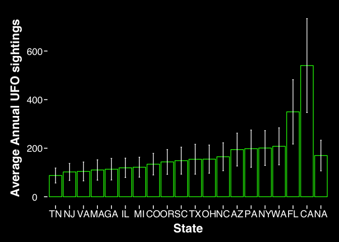

```r
##average number of UFO sightings per year by state
ggplot(df, aes(x=reorder(State,UFO_mean), y=UFO_mean))+
  geom_bar(stat="identity", color="green", fill="black")+
  geom_errorbar(aes(ymin=UFO_mean - UFO_se, ymax=UFO_mean + UFO_se), width=.1, color="white")+
  labs(x="State", y="Average Annual UFO sightings")+
  theme_UFO()
```